# Neha Dixit_Unit2_HW2

Neha Dixit

5/18/2019

# Question 1

## a. What is a basic workflow for reproducible research?

The basic workflow of reproducible research include-  
* Data gathering * Data analysis  
* Result presentation

## b. What are five practical tips for making research reproducible?

The five pratical tips for making research reproducible are -  
* Document everything  
* Everything is a (text) file  
* All files should be human readable  
* Explicitly tie your files together  
* Have a plan to organize , store and make your files available

## c. Give an example of how you might implement each tip.

Below is an example of using language R and implementing research reproducible code-

- Document everything

It is important to document the entire research as it makes it easier for the researcher to trace back the research and also for others to be able to reproduce it. Also, the version of the software packages change with time and vary across different operating systems. A well documented research in this case will be very helpful when trying to reproduce. Example- sessionInfo() commandin R prints all the information related to what packages and versions were used during the research with done using R.

[session information not shown]

- Everything is a (text) file

All the research should be documented to be reproducible and the easiest file format to document is text file as it can easily store the data in comma separated formated and is accessible by wide variety of current programs like R, LaTex etc.Text files are easy to search, manipulate and version control can be easily done with programs like github

- All files should be human readable

The research should be maintained in human readble format by commenting and formating the code using styl guide as often as possible. In R commenting can be done using # as shown below .

# Commenting this code

It is a good practice to include the description of whatis done in the file, who created the file and when in the comment section.The two common practices to make the research more readable are using style guides ( in R formatR package can be used) and literate programming( including the important pieces of the code in the presentation text format to explain it further( in appendix section of the document)

- Explicitly Tie your files together

The research documents can be text files with data , PDF document presenting results etc. and it is very important for the current or the future researchers to be able to tie all the files to be able to read or reproduce the research. Hence, it is important to link all the files together.Example - knitr package used to analyze code in presentation format and tie R code

- Have a plan to organize store and make files available Tools like Github and dropbox can be used to store and organize the files and share it.

# Question 2

## a. As described in the “TODO Assignment 2: Question 2a” comment, complete the plot function regarding monthly temperature.

```r
str(airquality)
```

```
## 'data.frame':    153 obs. of  6 variables:
##  $ Ozone  : int  41 36 12 18 NA 28 23 19 8 NA ...
##  $ Solar.R: int  190 118 149 313 NA NA 299 99 19 194 ...
##  $ Wind   : num  7.4 8 12.6 11.5 14.3 14.9 8.6 13.8 20.1 8.6 ...
##  $ Temp   : int  67 72 74 62 56 66 65 59 61 69 ...
##  $ Month  : int  5 5 5 5 5 5 5 5 5 5 ...
##  $ Day    : int  1 2 3 4 5 6 7 8 9 10 ...
```

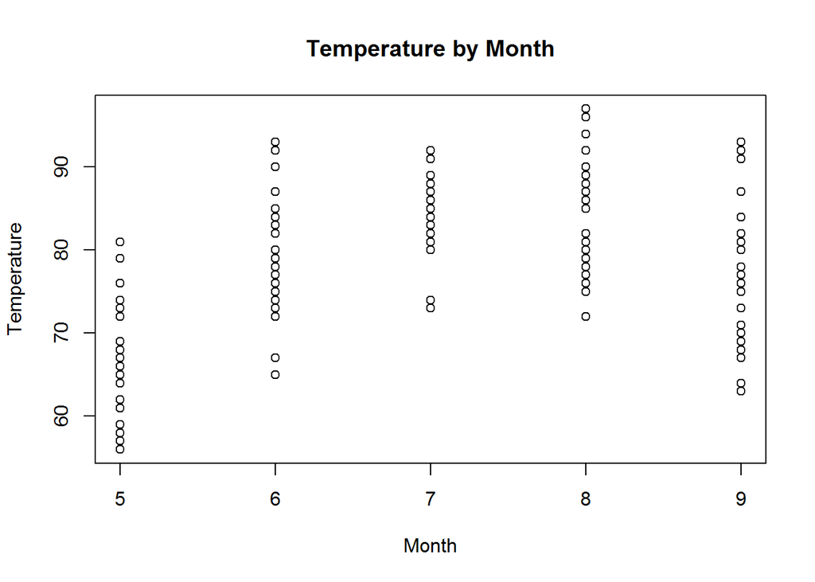

```r
### Take only Temp columns
Temperature <- airquality$Temp


#Make the x label "Month" and the y label "Temperature"
#Make the title of the plot "Temperature by Month"
#Plot with added parameters
plot(x=airquality$Month, y=Temperature,xlab="Month",ylab="Temperature",main="Temperature by Month" )
```

## b. As described in the “TODO Assignment 2: Question 2b” comment, complete the plot function involving ozone.

```r
str(airquality)
```

```
## 'data.frame':    153 obs. of  6 variables:
##  $ Ozone  : int  41 36 12 18 NA 28 23 19 8 NA ...
##  $ Solar.R: int  190 118 149 313 NA NA 299 99 19 194 ...
##  $ Wind   : num  7.4 8 12.6 11.5 14.3 14.9 8.6 13.8 20.1 8.6 ...
##  $ Temp   : int  67 72 74 62 56 66 65 59 61 69 ...
##  $ Month  : int  5 5 5 5 5 5 5 5 5 5 ...
##  $ Day    : int  1 2 3 4 5 6 7 8 9 10 ...
```

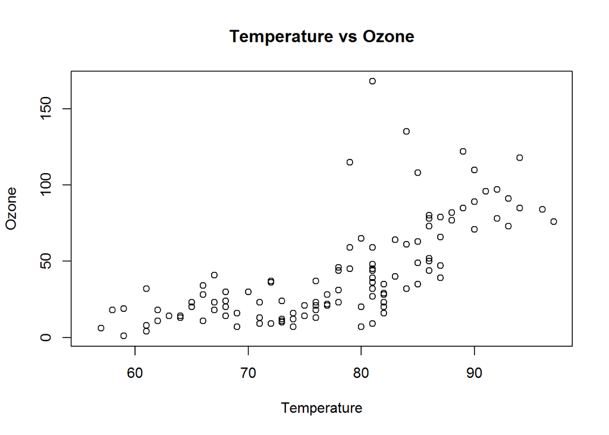

```r
### Take only Temp columns
Temperature <- airquality$Temp


# Make the x label "Temperature" and the y label "Ozone",
# Make the title of the plot "Temperature vs Ozone"
Ozone <- airquality$Ozone

plot(x=Temperature, y=Ozone,xlab="Temperature",ylab="Ozone",main="Temperature vs Ozone" )
```

# Question 3

## a. As described in the “TODO Assignment 2: Question 3a” comment, complete a plot function for Temperature and Pressure.

```r
summary(pressure)
```

```
##   temperature     pressure
##  Min.   :  0   Min.   :  0.0002
##  1st Qu.: 90   1st Qu.:  0.1800
##  Median :180   Median :  8.8000
##  Mean   :180   Mean   :124.3367
##  3rd Qu.:270   3rd Qu.:126.5000
##  Max.   :360   Max.   :806.0000
```

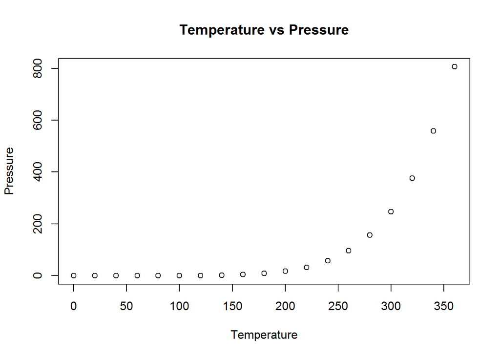

```r
plot(pressure,xlab="Temperature",ylab="Pressure",main="Temperature vs Pressure")
```

## b. As described in the “TODO Assignment 2: Question 3b” comment, complete a similar plot function that reverses the two axes.

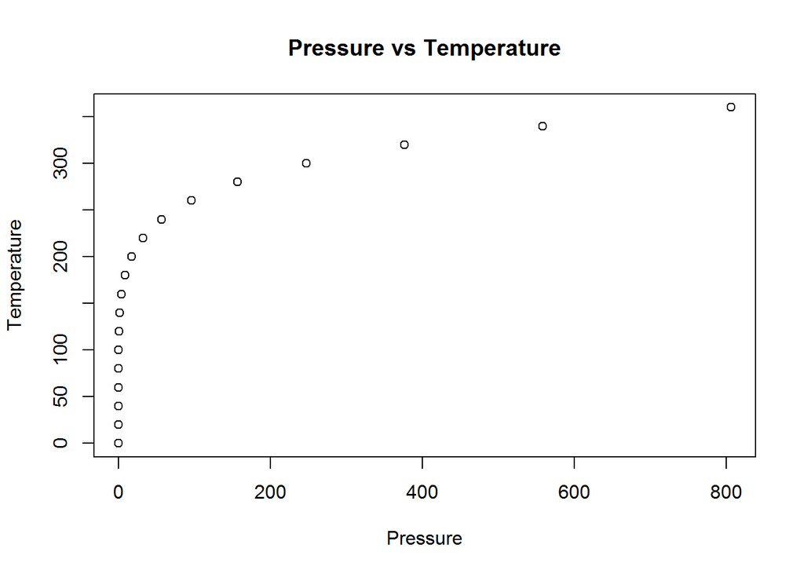

```r
plot(pressure$pressure,pressure$temperature,xlab="Pressure",ylab="Temperature",main="Pressure vs Temperature")
```